# Psychometric Evaluation and Validation of Bangla Rotter Internal-External Scale with Classical Test Theory and Item Response theory

Mushfiqul Anwar Siraji

2022-08-02

# 1 Preparing the R environment

```r
# Run this to install the required packages.
install.packages("pacman")
pacman::p_load(devtools,tidyverse, psych, mirt, lavaan, VIM, semPower, labelled, MOTE, semTools, knitr, kableExtra)
devtools::install_github("crsh/papaja", force = T)
devtools::install_github('SachaEpskamp/semPlot',  dependencies = T)
remotes::install_github("ddsjoberg/gtsummary")
```

```r
library(tidyverse)
library(psych)
library(mirt)
library(lavaan)
library(gtsummary)
library(VIM)
library(tabledown)
library(semPower)
library(labelled)
library(MOTE)
library(semTools)
library(papaja)
library(knitr)
library(kableExtra)
papaja::r_refs("Rotter-References.bib")
```

# 2 Sample size estimation

- For EFA generally a sample size of 250-300 is required (Schönbrodt and Perugini 2013; Comrey and Lee 1992).
- For CFA we should follow n:q rule where at least 5/10/20 participants are required per item (Jackson 2011; Worthington and Whittaker 2006; Bentler and Chou 1987; Kline 2015).
- For IRT it should be around 500. But should use a monte carlo simulation for sample size estimation.

```r
lavmodel <-  "LOC =~ item18 + item25 +item11 + item15 + item16 + item10 +item9 +
item23 + item13 + item5 + item28 + item4"
df <- semPower::semPower.getDf(lavmodel)

ap <- semPower::semPower.aPriori(effect = .05, effect.measure = 'RMSEA', alpha = .05,
                       power = .80, df = df)
summary(ap)
```

```
##
##  semPower: A-priori power analysis
##
##  F0                        0.135000
##  RMSEA                     0.050000
##  Mc                        0.934728
##
##  df                        54
##  Required Num Observations 233
##
##  Critical Chi-Square       72.15321
##  NCP                       31.32000
##  Alpha                     0.050000
##  Beta                      0.197590
##  Power (1-beta)            0.802410
##  Implied Alpha/Beta Ratio  0.253049
```

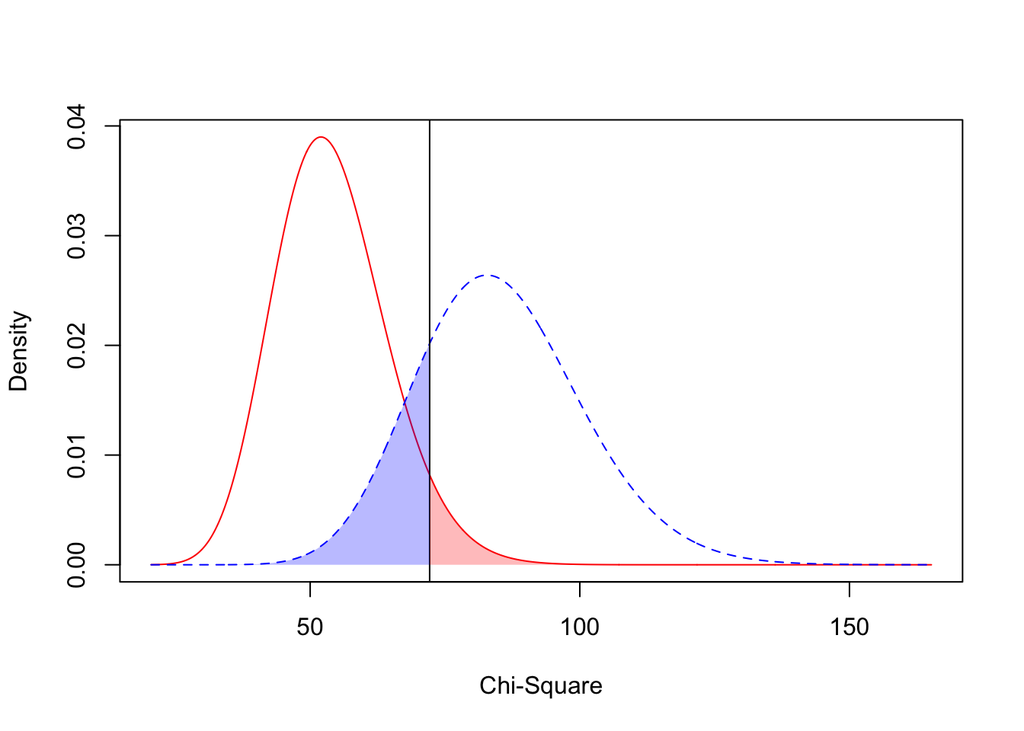

# 3 Data analysis

## 3.1 Load and subset the data

```r
#Load the data
data_0 <- readRDS("WRotter.rds")
data <- labelled::remove_labels(data_0)
##EFA data
Rotter.EFA <- data[1:300,11:33]
##EFA Descriptivs
efa.descriptives <- data[1:300,c(3,4,5,6,7,8)]
##CFA Data
Rotter.CFA <- data[301:478, 11:33]
##CFA Descriptives
cfa.descriptives <- data[301:478,c(3,4,5,6,7,8)]
##IRT data
WRotter.IRT <- data[,11:33]
##IRT Descriptives
irt.descriptives <- data[,c(3,4,5,6,7,8)]

## Data for descriptives (Publication)
Descriptives.pub <- data %>%
  dplyr::select("Gender", "Age", "Education Years", "Social Stance","Marital Status","sample")
```

## 3.2 Cheack missing values

```r
#Check Missing Values
missing.EFA <- VIM::aggr(Rotter.EFA, plot =T)
```

[output not shown]

```r
missing.CFA<- VIM::aggr(Rotter.CFA, plot =T)
```

[output not shown]

```r
missing.IRT <- VIM::aggr(WRotter.IRT, plot =T)
```

[output not shown]

Our data has no missing values.

## 3.3 Descriptive statistics

There are several ways of getting the descriptive summary. At first we will do it using **psych**(Revelle 2021) package to get item-summary.

```r
Descriptives <- psych::describe(Rotter.EFA)
Descriptives %>%
  knitr::kable(caption = "Descriptives", col.names = NA, digits = 2) %>%
  kableExtra::kable_styling(bootstrap_options = "striped", full_width = F) %>%
    scroll_box(width = "100%", height = "450px")
```

Table 3.1: Descriptives

|  | vars | n | mean | sd | median | trimmed | mad | min | max | range | skew | kurtosis | se |
| --- | --- | --- | --- | --- | --- | --- | --- | --- | --- | --- | --- | --- | --- |
| item2 | 1 | 300 | 0.17 | 0.37 | 0 | 0.08 | 0 | 0 | 1 | 1 | 1.78 | 1.17 | 0.02 |
| item3 | 2 | 300 | 0.87 | 0.34 | 1 | 0.96 | 0 | 0 | 1 | 1 | -2.15 | 2.62 | 0.02 |
| item4 | 3 | 300 | 0.43 | 0.50 | 0 | 0.41 | 0 | 0 | 1 | 1 | 0.30 | -1.92 | 0.03 |
| item5 | 4 | 300 | 0.14 | 0.34 | 0 | 0.05 | 0 | 0 | 1 | 1 | 2.10 | 2.44 | 0.02 |
| item6 | 5 | 300 | 0.32 | 0.47 | 0 | 0.28 | 0 | 0 | 1 | 1 | 0.75 | -1.44 | 0.03 |
| item7 | 6 | 300 | 0.85 | 0.35 | 1 | 0.94 | 0 | 0 | 1 | 1 | -1.99 | 1.96 | 0.02 |
| item9 | 7 | 300 | 0.29 | 0.45 | 0 | 0.23 | 0 | 0 | 1 | 1 | 0.94 | -1.12 | 0.03 |
| item10 | 8 | 300 | 0.08 | 0.28 | 0 | 0.00 | 0 | 0 | 1 | 1 | 3.00 | 7.02 | 0.02 |
| item11 | 9 | 300 | 0.53 | 0.50 | 1 | 0.53 | 0 | 0 | 1 | 1 | -0.11 | -2.00 | 0.03 |
| item12 | 10 | 300 | 0.49 | 0.50 | 0 | 0.49 | 0 | 0 | 1 | 1 | 0.03 | -2.01 | 0.03 |
| item13 | 11 | 300 | 0.55 | 0.50 | 1 | 0.56 | 0 | 0 | 1 | 1 | -0.20 | -1.97 | 0.03 |
| item15 | 12 | 300 | 0.54 | 0.50 | 1 | 0.55 | 0 | 0 | 1 | 1 | -0.17 | -1.98 | 0.03 |
| item16 | 13 | 300 | 0.29 | 0.45 | 0 | 0.24 | 0 | 0 | 1 | 1 | 0.92 | -1.16 | 0.03 |
| item17 | 14 | 300 | 0.81 | 0.40 | 1 | 0.88 | 0 | 0 | 1 | 1 | -1.55 | 0.39 | 0.02 |
| item18 | 15 | 300 | 0.80 | 0.40 | 1 | 0.88 | 0 | 0 | 1 | 1 | -1.52 | 0.31 | 0.02 |
| item20 | 16 | 300 | 0.52 | 0.50 | 1 | 0.52 | 0 | 0 | 1 | 1 | -0.07 | -2.00 | 0.03 |
| item21 | 17 | 300 | 0.22 | 0.41 | 0 | 0.15 | 0 | 0 | 1 | 1 | 1.37 | -0.13 | 0.02 |
| item22 | 18 | 300 | 0.26 | 0.44 | 0 | 0.20 | 0 | 0 | 1 | 1 | 1.09 | -0.82 | 0.03 |
| item23 | 19 | 300 | 0.09 | 0.29 | 0 | 0.00 | 0 | 0 | 1 | 1 | 2.78 | 5.76 | 0.02 |
| item25 | 20 | 300 | 0.62 | 0.49 | 1 | 0.65 | 0 | 0 | 1 | 1 | -0.51 | -1.75 | 0.03 |
| item26 | 21 | 300 | 0.72 | 0.45 | 1 | 0.78 | 0 | 0 | 1 | 1 | -0.98 | -1.05 | 0.03 |
| item28 | 22 | 300 | 0.20 | 0.40 | 0 | 0.13 | 0 | 0 | 1 | 1 | 1.47 | 0.15 | 0.02 |
| item29 | 23 | 300 | 0.45 | 0.50 | 0 | 0.44 | 0 | 0 | 1 | 1 | 0.19 | -1.97 | 0.03 |

**Skewness >2.0** and **Kurtosis > 7.0** indicate severe uni-variate non normality.

Now we will try **gtsummary** (Sjoberg et al. 2021) package to get descriptive statistics of the sample.

```r
clear.labels <- function(x) {
  if(is.list(x)) {
    for(i in 1 : length(x)) class(x[[i]]) <- setdiff(class(x[[i]]), 'labelled')
    for(i in 1 : length(x)) attr(x[[i]],"label") <- NULL
  }
  else {
    class(x) <- setdiff(class(x), "labelled")
    attr(x, "label") <- NULL
  }
  return(x)
}
Descriptives.pub <- clear.labels(Descriptives.pub)

desc_sample <-  gtsummary::tbl_summary(Descriptives.pub,
                                      by = sample,
                                      statistic = list(
                                        all_continuous() ~ "{mean} ({sd})",
                                        all_categorical() ~ "{n} ({p}%)"),
                                      type = list(`Education Years` ~ 'continuous'),
                                      digits = all_continuous() ~ 2,
                                      missing = "no") %>%
  modify_caption("**Descriptive Statistics of the Sample:1**") %>%
  add_overall() %>% add_p()


desc_gender <-  gtsummary::tbl_summary(Descriptives.pub,
                                      by = Gender,
                                      statistic = list(
                                        all_continuous() ~ "{mean} ({sd})",
                                        all_categorical() ~ "{n} ({p}%)"),
                                      type = list(`Education Years` ~ 'continuous'),
                                      digits = all_continuous() ~ 2,
                                      missing = "no") %>%add_overall()%>% add_p() %>%
  modify_caption("**Descriptive Statistics of the Sample:2**")

desc_sample
```

Table 3.2: **Descriptive Statistics of the Sample:1**

| **Characteristic** | **Overall**, N = 478<sup>1</sup> | **CFA**, N = 178<sup>1</sup> | **EFA**, N = 300<sup>1</sup> | **p-value**<sup>2</sup> |
| --- | --- | --- | --- | --- |
| Gender |  |  |  | 0.12 |
| Female | 326 (68%) | 129 (72%) | 197 (66%) |  |
| Male | 152 (32%) | 49 (28%) | 103 (34%) |  |
| Age | 30.32 (4.95) | 30.37 (5.04) | 30.29 (4.91) | 0.7 |
| Education Years | 15.71 (1.93) | 15.62 (1.97) | 15.77 (1.91) | 0.3 |
| Social Stance | 6.71 (2.13) | 6.71 (2.06) | 6.71 (2.17) | 0.8 |
| Marital Status |  |  |  | 0.006 |
| 1 | 121 (25%) | 35 (20%) | 86 (29%) |  |
| 2 | 354 (74%) | 140 (79%) | 214 (71%) |  |
| 3 | 3 (0.6%) | 3 (1.7%) | 0 (0%) |  |

<sup>1</sup> n (%); Mean (SD)  
<sup>2</sup> Pearson's Chi-squared test; Wilcoxon rank sum test; Fisher's exact test

```r
desc_gender
```

Table 3.2: **Descriptive Statistics of the Sample:2**

| **Characteristic** | **Overall**, N = 478<sup>1</sup> | **Female**, N = 326<sup>1</sup> | **Male**, N = 152<sup>1</sup> | **p-value**<sup>2</sup> |
| --- | --- | --- | --- | --- |
| Age | 30.32 (4.95) | 29.18 (4.93) | 32.77 (4.05) | <0.001 |
| Education Years | 15.71 (1.93) | 15.23 (2.11) | 16.74 (0.80) | <0.001 |
| Social Stance | 6.71 (2.13) | 6.54 (2.11) | 7.08 (2.14) | 0.005 |
| Marital Status |  |  |  | 0.3 |
| 1 | 121 (25%) | 87 (27%) | 34 (22%) |  |
| 2 | 354 (74%) | 236 (72%) | 118 (78%) |  |
| 3 | 3 (0.6%) | 3 (0.9%) | 0 (0%) |  |
| sample |  |  |  | 0.12 |
| CFA | 178 (37%) | 129 (40%) | 49 (32%) |  |
| EFA | 300 (63%) | 197 (60%) | 103 (68%) |  |

<sup>1</sup> Mean (SD); n (%)  
<sup>2</sup> Wilcoxon rank sum test; Fisher's exact test; Pearson's Chi-squared test

## 3.4 Assumptions

### 3.4.1 Univariate normality

Now we will try to look into item summary using **tabledown** package. Here we will check the univariate normality

```r
des.tab <- tabledown::des.tab(Rotter.EFA)

papaja::apa_table(des.tab, caption= "A beautiful table describing the item summary ")
```

Table 3.3:

*A beautiful table describing the item summary*

| Items | Mean | SD | Skew | Kurtosis | Normality | Corrected.item.total.correlation |
| --- | --- | --- | --- | --- | --- | --- |
| item2 | 0.17 | 0.37 | 1.78 | 1.17 | 0.45* | 0.24 |
| item3 | 0.87 | 0.34 | -2.15 | 2.62 | 0.40* | 0.13 |
| item4 | 0.43 | 0.50 | 0.30 | -1.92 | 0.63* | 0.28 |
| item5 | 0.14 | 0.34 | 2.10 | 2.44 | 0.41* | 0.25 |
| item6 | 0.32 | 0.47 | 0.75 | -1.44 | 0.59* | 0.08 |
| item7 | 0.85 | 0.35 | -1.99 | 1.96 | 0.42* | 0.23 |
| item9 | 0.29 | 0.45 | 0.94 | -1.12 | 0.57* | 0.41 |
| item10 | 0.08 | 0.28 | 3.00 | 7.02 | 0.31* | 0.29 |
| item11 | 0.53 | 0.50 | -0.11 | -2.00 | 0.64* | 0.44 |
| item12 | 0.49 | 0.50 | 0.03 | -2.01 | 0.64* | 0.29 |
| item13 | 0.55 | 0.50 | -0.20 | -1.97 | 0.63* | 0.39 |
| item15 | 0.54 | 0.50 | -0.17 | -1.98 | 0.63* | 0.47 |
| item16 | 0.29 | 0.45 | 0.92 | -1.16 | 0.57* | 0.39 |
| item17 | 0.81 | 0.40 | -1.55 | 0.39 | 0.48* | 0.17 |
| item18 | 0.80 | 0.40 | -1.52 | 0.31 | 0.49* | 0.50 |
| item20 | 0.52 | 0.50 | -0.07 | -2.00 | 0.64* | 0.22 |
| item21 | 0.22 | 0.41 | 1.37 | -0.13 | 0.51* | 0.26 |
| item22 | 0.26 | 0.44 | 1.09 | -0.82 | 0.55* | 0.24 |
| item23 | 0.09 | 0.29 | 2.78 | 5.76 | 0.33* | 0.35 |
| item25 | 0.62 | 0.49 | -0.51 | -1.75 | 0.61* | 0.53 |
| item26 | 0.72 | 0.45 | -0.98 | -1.05 | 0.56* | 0.20 |
| item28 | 0.20 | 0.40 | 1.47 | 0.15 | 0.49* | 0.29 |
| item29 | 0.45 | 0.50 | 0.19 | -1.97 | 0.63* | 0.22 |

### 3.4.2 Multivariate normality

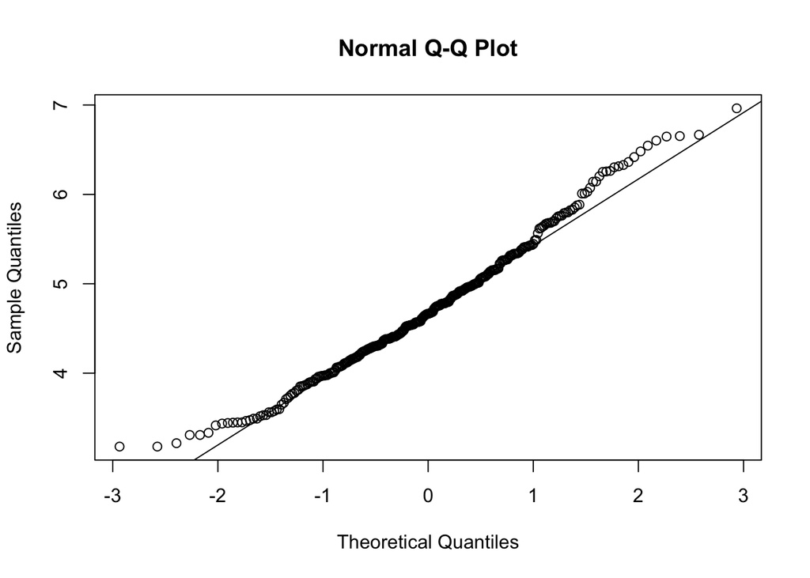

```r
mardia <- mardia(Rotter.EFA, na.rm = T, plot =T)
```

## 3.5 Corrleaton matrix

```r
correlations <- psych::tetrachoric(Rotter.EFA,smooth=TRUE)
```

```r
upper <- correlations$rho[upper.tri(correlations$rho, diag = F)]

range.cor <- range(upper)

##Quality of the matrix
bartlet <- psych::cortest.bartlett(Rotter.EFA, n =300)
```

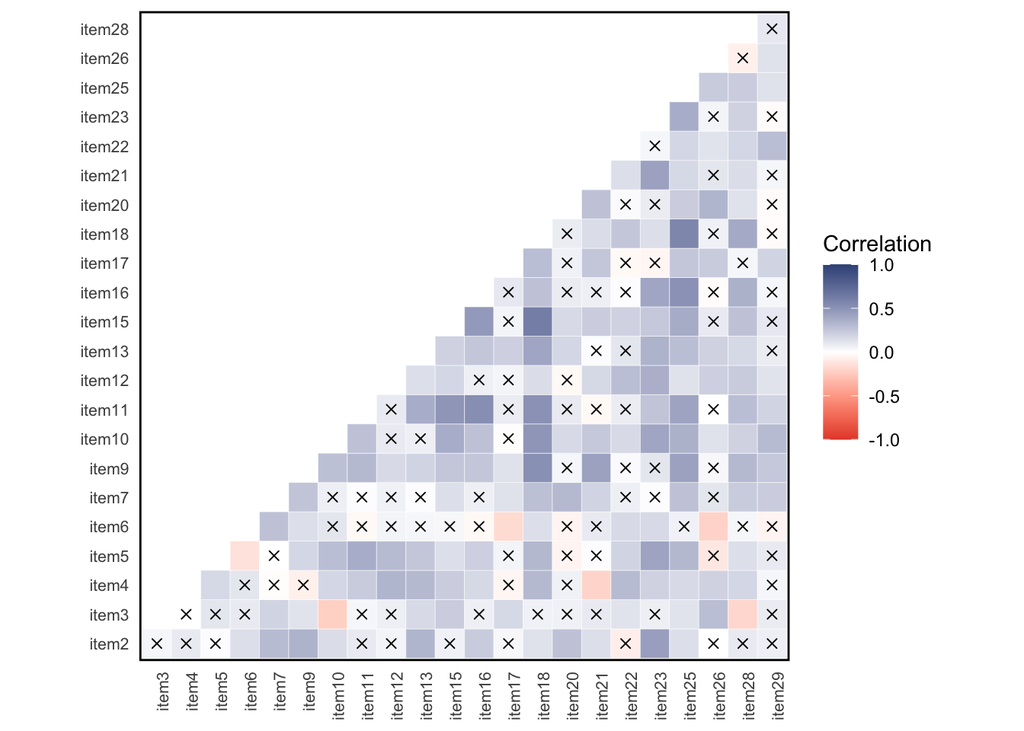

```r
p.mat <- correlation::cor_to_p(correlations$rho, 300, method = "tetrachoric")

corplot <- ggcorrplot::ggcorrplot(correlations$rho, p.mat=p.mat$p, insig = "pch", hc.order = FALSE, outline.col = "white", type = "lower", legend.title = "Correlation",sig.level = 0.05, pch.cex=1.8,
                                  # insig = "blank",
                                  ggtheme = ggplot2::theme_minimal(),tl.srt = 90,colors = c("#E64B35FF", "white", "#3C5488FF") )+
  theme( panel.grid.major = element_blank(),
         axis.text.x = element_text(size = 8),
         axis.text.y = element_text(size = 8),
         panel.border = element_rect(color = "black",
                                     fill = NA,
                                     size = 1))

corplot
```

## 3.6 Item analysis: classical test theory

Before starting the EFA, executing an item analysis will give us idea about the quality of the items.

```r
Cron.bach <- psych::alpha(Rotter.EFA, check.keys = T)
Cron.bach$total %>%
  knitr::kable(caption = "Alpha", digits = 2) %>%
  kableExtra::kable_styling(bootstrap_options = "striped", full_width = F)
```

Table 3.4: Alpha

|  | raw_alpha | std.alpha | G6(smc) | average_r | S/N | ase | mean | sd | median_r |
| --- | --- | --- | --- | --- | --- | --- | --- | --- | --- |
|  | 0.68 | 0.68 | 0.71 | 0.09 | 2.15 | 0.03 | 0.45 | 0.15 | 0.08 |

```r
Cron.bach$alpha.drop %>%
  knitr::kable(caption = "Alpha value if item is dropped", digits = 2) %>%
  kableExtra::kable_styling(bootstrap_options = "striped", full_width = F)
```

Table 3.4: Alpha value if item is dropped

|  | raw_alpha | std.alpha | G6(smc) | average_r | S/N | alpha se | var.r | med.r |
| --- | --- | --- | --- | --- | --- | --- | --- | --- |
| item2 | 0.68 | 0.68 | 0.71 | 0.09 | 2.10 | 0.03 | 0.01 | 0.08 |
| item3 | 0.68 | 0.69 | 0.71 | 0.09 | 2.18 | 0.03 | 0.01 | 0.08 |
| item4 | 0.68 | 0.68 | 0.70 | 0.09 | 2.08 | 0.03 | 0.01 | 0.07 |
| item5 | 0.68 | 0.68 | 0.71 | 0.09 | 2.10 | 0.03 | 0.01 | 0.08 |
| item6 | 0.69 | 0.69 | 0.72 | 0.09 | 2.22 | 0.03 | 0.01 | 0.08 |
| item7 | 0.68 | 0.68 | 0.71 | 0.09 | 2.10 | 0.03 | 0.01 | 0.08 |
| item9 | 0.67 | 0.66 | 0.69 | 0.08 | 1.98 | 0.03 | 0.01 | 0.07 |
| item10 | 0.68 | 0.67 | 0.70 | 0.09 | 2.07 | 0.03 | 0.01 | 0.08 |
| item11 | 0.66 | 0.66 | 0.69 | 0.08 | 1.96 | 0.03 | 0.01 | 0.08 |
| item12 | 0.67 | 0.67 | 0.70 | 0.09 | 2.06 | 0.03 | 0.01 | 0.07 |
| item13 | 0.66 | 0.67 | 0.70 | 0.08 | 1.99 | 0.03 | 0.01 | 0.07 |
| item15 | 0.66 | 0.66 | 0.69 | 0.08 | 1.94 | 0.03 | 0.01 | 0.07 |
| item16 | 0.67 | 0.67 | 0.69 | 0.08 | 1.99 | 0.03 | 0.01 | 0.08 |
| item17 | 0.68 | 0.68 | 0.71 | 0.09 | 2.16 | 0.03 | 0.01 | 0.08 |
| item18 | 0.66 | 0.66 | 0.68 | 0.08 | 1.92 | 0.03 | 0.01 | 0.07 |
| item20 | 0.68 | 0.68 | 0.71 | 0.09 | 2.12 | 0.03 | 0.01 | 0.08 |
| item21 | 0.68 | 0.68 | 0.70 | 0.09 | 2.09 | 0.03 | 0.01 | 0.08 |
| item22 | 0.68 | 0.68 | 0.71 | 0.09 | 2.10 | 0.03 | 0.01 | 0.08 |
| item23 | 0.67 | 0.67 | 0.70 | 0.08 | 2.03 | 0.03 | 0.01 | 0.08 |
| item25 | 0.65 | 0.65 | 0.68 | 0.08 | 1.89 | 0.03 | 0.01 | 0.07 |
| item26 | 0.68 | 0.68 | 0.71 | 0.09 | 2.14 | 0.03 | 0.01 | 0.08 |
| item28 | 0.67 | 0.67 | 0.70 | 0.09 | 2.06 | 0.03 | 0.01 | 0.07 |
| item29 | 0.68 | 0.68 | 0.71 | 0.09 | 2.12 | 0.03 | 0.01 | 0.08 |

```r
Cron.bach$item.stats %>%
  knitr::kable(caption = "Corrected Item total Correlation", digits = 2) %>%
  kableExtra::kable_styling(bootstrap_options = "striped", full_width = F)
```

Table 3.4: Corrected Item total Correlation

|  | n | raw.r | std.r | r.cor | r.drop | mean | sd |
| --- | --- | --- | --- | --- | --- | --- | --- |
| item2 | 300 | 0.29 | 0.31 | 0.24 | 0.19 | 0.17 | 0.37 |
| item3 | 300 | 0.21 | 0.23 | 0.13 | 0.11 | 0.87 | 0.34 |
| item4 | 300 | 0.36 | 0.34 | 0.28 | 0.23 | 0.43 | 0.50 |
| item5 | 300 | 0.29 | 0.31 | 0.25 | 0.19 | 0.14 | 0.34 |
| item6 | 300 | 0.18 | 0.18 | 0.08 | 0.05 | 0.32 | 0.47 |
| item7 | 300 | 0.29 | 0.31 | 0.23 | 0.19 | 0.85 | 0.35 |
| item9 | 300 | 0.44 | 0.44 | 0.41 | 0.32 | 0.29 | 0.45 |
| item10 | 300 | 0.31 | 0.35 | 0.29 | 0.23 | 0.08 | 0.28 |
| item11 | 300 | 0.48 | 0.46 | 0.44 | 0.36 | 0.53 | 0.50 |
| item12 | 300 | 0.37 | 0.35 | 0.29 | 0.24 | 0.49 | 0.50 |
| item13 | 300 | 0.45 | 0.43 | 0.39 | 0.33 | 0.55 | 0.50 |
| item15 | 300 | 0.51 | 0.49 | 0.47 | 0.39 | 0.54 | 0.50 |
| item16 | 300 | 0.43 | 0.43 | 0.39 | 0.32 | 0.29 | 0.45 |
| item17 | 300 | 0.24 | 0.25 | 0.17 | 0.14 | 0.81 | 0.40 |
| item18 | 300 | 0.51 | 0.50 | 0.50 | 0.41 | 0.80 | 0.40 |
| item20 | 300 | 0.31 | 0.30 | 0.22 | 0.17 | 0.52 | 0.50 |
| item21 | 300 | 0.31 | 0.32 | 0.26 | 0.19 | 0.22 | 0.41 |
| item22 | 300 | 0.32 | 0.31 | 0.24 | 0.20 | 0.26 | 0.44 |
| item23 | 300 | 0.35 | 0.39 | 0.35 | 0.27 | 0.09 | 0.29 |
| item25 | 300 | 0.55 | 0.53 | 0.53 | 0.44 | 0.62 | 0.49 |
| item26 | 300 | 0.28 | 0.27 | 0.20 | 0.16 | 0.72 | 0.45 |
| item28 | 300 | 0.35 | 0.35 | 0.29 | 0.25 | 0.20 | 0.40 |
| item29 | 300 | 0.30 | 0.29 | 0.22 | 0.17 | 0.45 | 0.50 |

## 3.7 Factor analysis

## 3.8 Sampling adequacy: KMO

```r
KMO <- KMO(Rotter.EFA)
kmo.value <- KMO$MSA
```

Minimum cut off is **.50** (Kaiser 1974). Our Overall value is 0.68.

```r
KMO$MSAi%>%
knitr::kable(caption = "Item-Wise Value", digits = 2) %>%
  kableExtra::kable_styling(bootstrap_options = "striped", full_width = F) %>%
  scroll_box(width = "200px", height = "450px")
```

Table 3.5: Item-Wise Value

|  | x |
| --- | --- |
| item2 | 0.60 |
| item3 | 0.53 |
| item4 | 0.70 |
| item5 | 0.68 |
| item6 | 0.49 |
| item7 | 0.63 |
| item9 | 0.69 |
| item10 | 0.70 |
| item11 | 0.79 |
| item12 | 0.70 |
| item13 | 0.77 |
| item15 | 0.77 |
| item16 | 0.73 |
| item17 | 0.60 |
| item18 | 0.70 |
| item20 | 0.56 |
| item21 | 0.55 |
| item22 | 0.63 |
| item23 | 0.62 |
| item25 | 0.80 |
| item26 | 0.56 |
| item28 | 0.77 |
| item29 | 0.50 |

```r
min.kmo <- min(KMO$MSAi)
max.kmo <- max(KMO$MSAi)
```

Individual items KMO value ranges between 0.49- 0.80.

## 3.9 Identification of factors

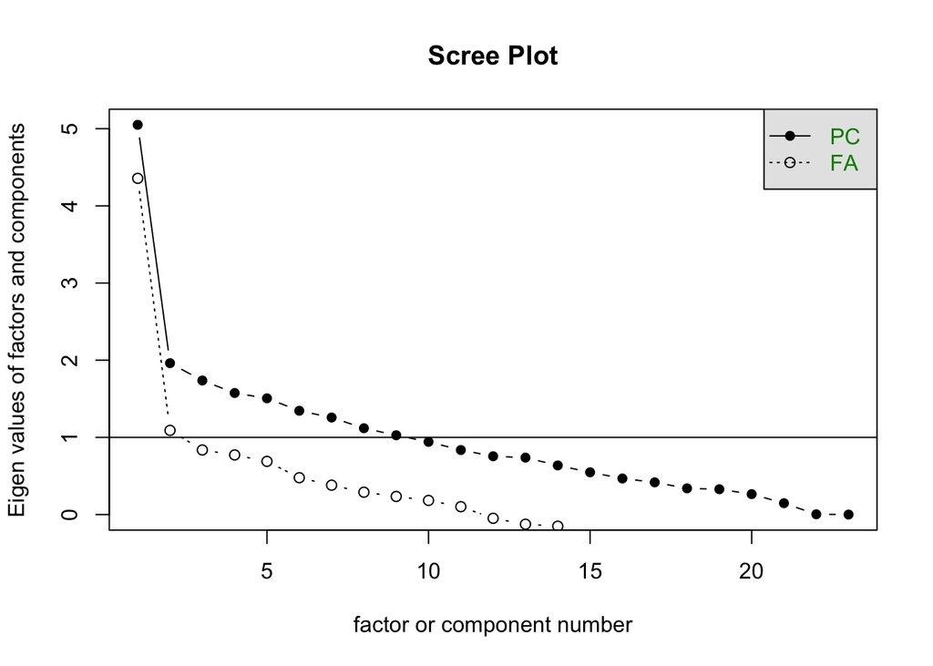

```r
scree(correlations$rho,factors=TRUE,pc=TRUE,main="Scree Plot",
               hline=NULL,add=F)
```

```
## HULL METHOD - CAF INDEX
##
##         q      f          g       st
##         0      0.3159   253       0.0000
##         1      0.5055   230       59.0831
##         2*     0.5066   208
##         3      0.5115   187       7.3624
##         4      0.5119   167       0.0254
##         5      0.5261   148       0.0000
##
## Number of advised dimensions: 1
## * Value outside the convex Hull
##
## -----------------------------------------------
```

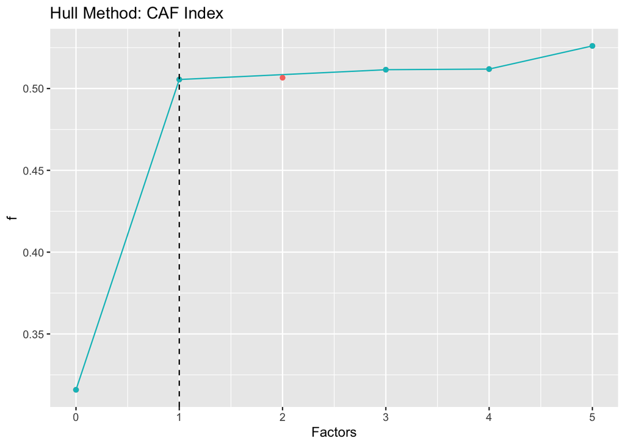

```r
EFA.MRFA::hullEFA(Rotter.EFA,extr = "ULS", index_hull = "CAF", display = TRUE,
                  graph = T,
                  details = TRUE)
```

## 3.10 Factor analysis

```r
Factor_analysis_tab <- FAc <-tabledown::fac.tab( fa.2F.2, .3, complexity = F)

papaja::apa_table(Factor_analysis_tab, caption= "A beautiful table describing the fator analysis output ")
```

Table 3.6:

*A beautiful table describing the fator analysis output*

| item | WLS1 | WLS2 | Communality | Uniqueness |
| --- | --- | --- | --- | --- |
| item11 | 0.73 |  | 0.538 | 0.462 |
| item18 | 0.73 |  | 0.57 | 0.43 |
| item15 | 0.62 |  | 0.432 | 0.568 |
| item16 | 0.59 |  | 0.353 | 0.647 |
| item10 | 0.5 |  | 0.273 | 0.727 |
| item23 | 0.49 |  | 0.305 | 0.695 |
| item5 | 0.49 |  | 0.24 | 0.76 |
| item28 | 0.45 |  | 0.206 | 0.794 |
| item13 | 0.44 |  | 0.249 | 0.751 |
| item4 | 0.39 |  | 0.152 | 0.848 |
| item12 |  |  | 0.107 | 0.893 |
| item20 |  | 0.53 | 0.285 | 0.715 |
| item21 |  | 0.48 | 0.24 | 0.76 |
| item7 |  | 0.45 | 0.212 | 0.788 |
| item26 |  | 0.45 | 0.205 | 0.795 |
| item2 |  | 0.35 | 0.167 | 0.833 |
| item17 |  | 0.31 | 0.101 | 0.899 |
| item3 |  | 0.3 | 0.093 | 0.907 |
| % of Variance | 0.18 | 0.08 |  |  |

## 3.11 Confirmatory factor analysis

```r
Rotter.one <- "LOC =~ item18 + item25 +item11 + item15 + item16 + item10 +item9 +
item23 + item13 + item5 + item28 + item4"

Rotter.one.fit <- cfa(Rotter.one,  Rotter.CFA,  mimic = "Mplus",
                      ordered = names(Rotter.CFA),estimator = "WLSMV")

One.factor.sum <- summary(Rotter.one.fit, fit.measures =TRUE,standardized = TRUE,
                          rsq =TRUE)

One.factor.Cfa <- fitmeasures (Rotter.one.fit,c("gfi", "agfi", "nfi","rfi",
                                                "cfi.scaled","tli.scaled",
                                                "rmsea",
                                                "srmr","aic"))



One.factor.reliability <- semTools::reliability(Rotter.one.fit)
# modfit.Cor.one <- modindices(Rotter.one.fit, sort. = TRUE)
# modfit.Cor.one[modfit.Cor.one$mi>3.84,]


Rotter.one.2 <- "LOC =~ item18 + item25 +item11 + item15 + item16 + item10 +item9 + item13 + item5 + item28 + item4"

Rotter.one.fit.2 <- cfa(Rotter.one.2,  Rotter.CFA,  mimic = "Mplus",
                        ordered = names(Rotter.CFA),estimator = "WLSMV")

One.factor.Cfa.mod.sum <- summary(Rotter.one.fit.2, fit.measures =TRUE,standardized = TRUE, rsq =TRUE)

One.factor.Cfa.mod.fit <- fitmeasures (Rotter.one.fit.2,c("gfi", "agfi", "nfi","rfi",
                                                          "cfi.scaled","tli.scaled",
                                                          "rmsea",
                                                          "srmr","aic"))


one.factor.cfaindices <- as.data.frame(One.factor.Cfa)
fitindices <- rownames_to_column(one.factor.cfaindices)
one.factor.cfaindices.mod <- as.data.frame(One.factor.Cfa.mod.fit)
cfatab1 <- cbind(fitindices,one.factor.cfaindices.mod   )
cfatab2 <- as.data.frame(t(cfatab1))
cfatab3 <- cfatab2[-1,-9]

One.factor.reliability.mod <- semTools::reliability(Rotter.one.fit.2)

# cfatab4 <- cbind(cfatab3,One.factor.reliability[5],One.factor.reliability.mod[5])
rownames(cfatab3) <- c("Model1: 12 items", "Model2: 11 items")
cfatab3$Reliability[1] <- One.factor.reliability[5]
cfatab3$Reliability[2] <- One.factor.reliability.mod[5]
```

```r
apa_table(cfatab3, caption= "CFA Fit Indices")
```

Table 3.7:

*CFA Fit Indices*

|  | gfi | agfi | nfi | rfi | cfi.scaled | tli.scaled | rmsea | srmr | Reliability |
| --- | --- | --- | --- | --- | --- | --- | --- | --- | --- |
| Model1: 12 items | 0.92654534 | 0.89389883 | 0.87125367 | 0.84264337 | 0.92277657 | 0.90561581 | 0.04191356 | 0.12781226 | 0.72 |
| Model2: 11 items | 0.9499168 | 0.9248751 | 0.9184239 | 0.8980298 | 0.9750735 | 0.9688419 | 0.0000000 | 0.1036453 | 0.72 |

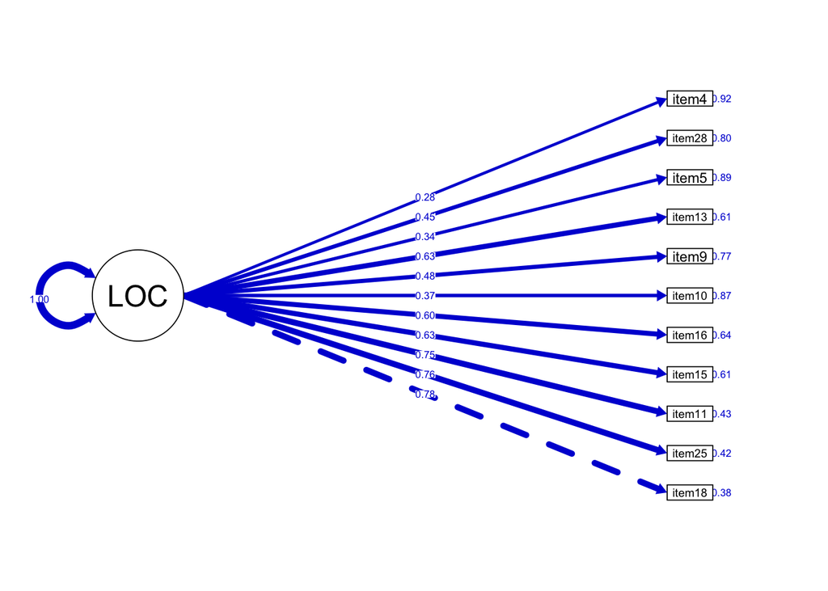

```r
CFA_plot1 <- semPlot::semPaths (Rotter.one.fit.2 ,
                                  what= "std",
                                  intercepts = F,
                                  style ="OpenMx",
                                  theme = "colorblind",
                                  nCharNodes = 0,
                                  reorder =T,
                                  rotation =2,
                                  layout ="tree",
                                  cardinal = T,
                                  curvePivot =T,
                                  sizeMan =6,#items length
                                  sizeMan2 = 2,#items
                                  sizeLat = 12,#factors
                                  thresholds = FALSE,
                                  equalizeManifests =F,
                                  fade = FALSE)
```

## 3.12 Item analysis: item response theory

```r
##Model Fit
unidim_fit_indices <- mirt::M2(unidimensional_fit)

##Item fit
unidimensional_itemfit <- mirt::itemfit(unidimensional_fit,
                                  fit_stats = c("S_X2", "G2","Zh", "infit"))

unidimensional_params <- mirt::coef(unidimensional_fit, IRTpars = TRUE, simplify = TRUE, rawug = FALSE)

unidimensional_items <- data.frame(unidimensional_params$items)

irt_parameters <- cbind(unidimensional_itemfit[,1], unidimensional_items[,c(1:2)], unidimensional_itemfit[, c(11:14)])

irt_marameters_names <- c("Item", "Discrimination", "Difficulty", "Signed-Chisquare", "df", "RMSEA", "p")

colnames(irt_parameters) <- irt_marameters_names
```

```r
papaja::apa_table(irt_parameters, caption = "IRT parameters")
```

Table 3.8:

*IRT parameters*

|  | Item | Discrimination | Difficulty | Signed-Chisquare | df | RMSEA | p |
| --- | --- | --- | --- | --- | --- | --- | --- |
| item18 | item18 | 2.21 | -1.09 | 6.42 | 4.00 | 0.04 | 0.17 |
| item25 | item25 | 1.64 | -0.55 | 9.82 | 6.00 | 0.04 | 0.13 |
| item11 | item11 | 1.80 | -0.04 | 2.96 | 6.00 | 0.00 | 0.81 |
| item15 | item15 | 1.41 | -0.14 | 3.78 | 6.00 | 0.00 | 0.71 |
| item16 | item16 | 1.47 | 0.78 | 2.52 | 6.00 | 0.00 | 0.87 |
| item10 | item10 | 0.96 | 2.79 | 9.33 | 6.00 | 0.03 | 0.16 |
| item9 | item9 | 0.95 | 0.98 | 4.24 | 7.00 | 0.00 | 0.75 |
| item13 | item13 | 0.98 | -0.16 | 5.21 | 7.00 | 0.00 | 0.63 |
| item5 | item5 | 0.77 | 2.40 | 4.41 | 7.00 | 0.00 | 0.73 |
| item28 | item28 | 0.87 | 1.55 | 1.04 | 7.00 | 0.00 | 0.99 |
| item4 | item4 | 0.49 | 0.31 | 9.94 | 7.00 | 0.03 | 0.19 |

```r
##Person-fit
unidimensional.personfit <- mirt::personfit(unidimensional_fit)

unidimensional.personfit_model_misfits <- subset(unidimensional.personfit, Zh < -2)

rownames(unidimensional.personfit_model_misfits)
```

```
##  [1] "66"  "86"  "98"  "198" "226" "302" "303" "327" "337" "339" "344" "379"
## [13] "476"
```

```r
nrow(unidimensional.personfit_model_misfits)
```

```
## [1] 13
```

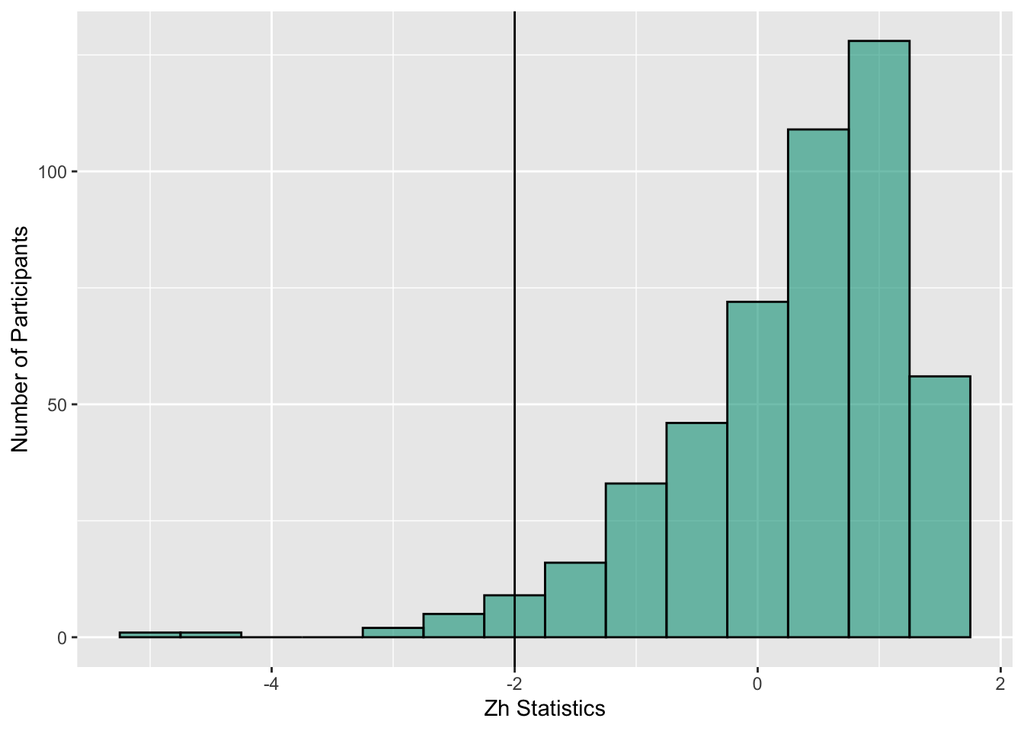

```r
personfit <- ggplot(unidimensional.personfit, aes(x=Zh)) + geom_histogram(binwidth=.5,col=I("black"),fill="#00A08799")+geom_vline(xintercept = -2)+
  labs( y="Number of Participants", x = "Zh Statistics")


personfit
```

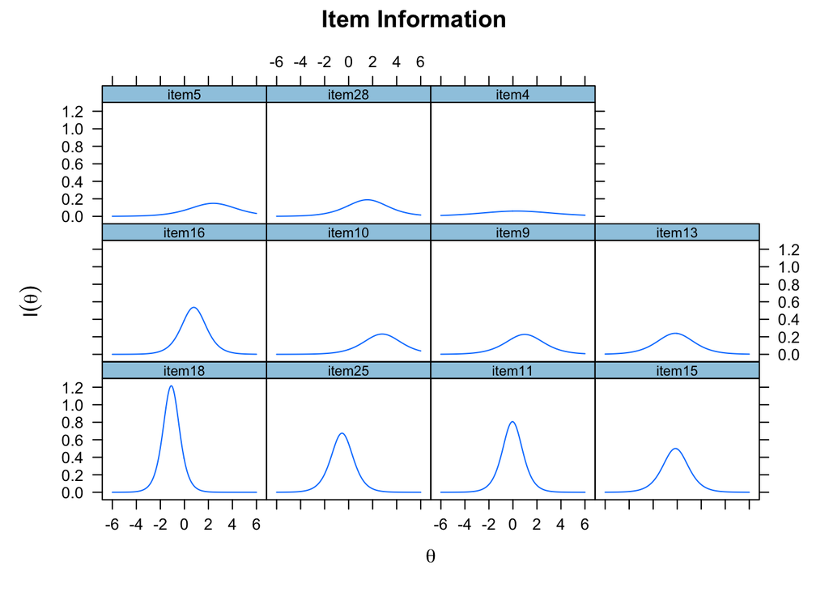

```r
#IRT Curves
## Conventionals
item_info <- mirt::plot(unidimensional_fit, type= "infotrace")
test_info <- mirt::plot(unidimensional_fit, type= "info")
occ_info <- mirt::plot(unidimensional_fit, type= "trace")

item_info
```

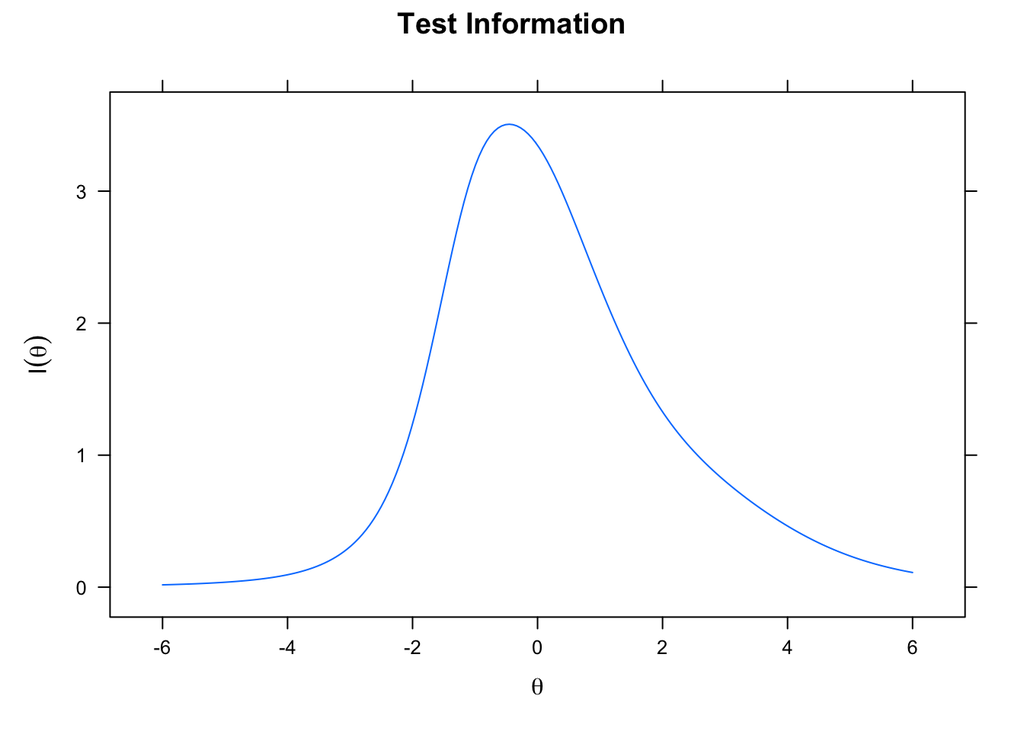

```r
test_info
```

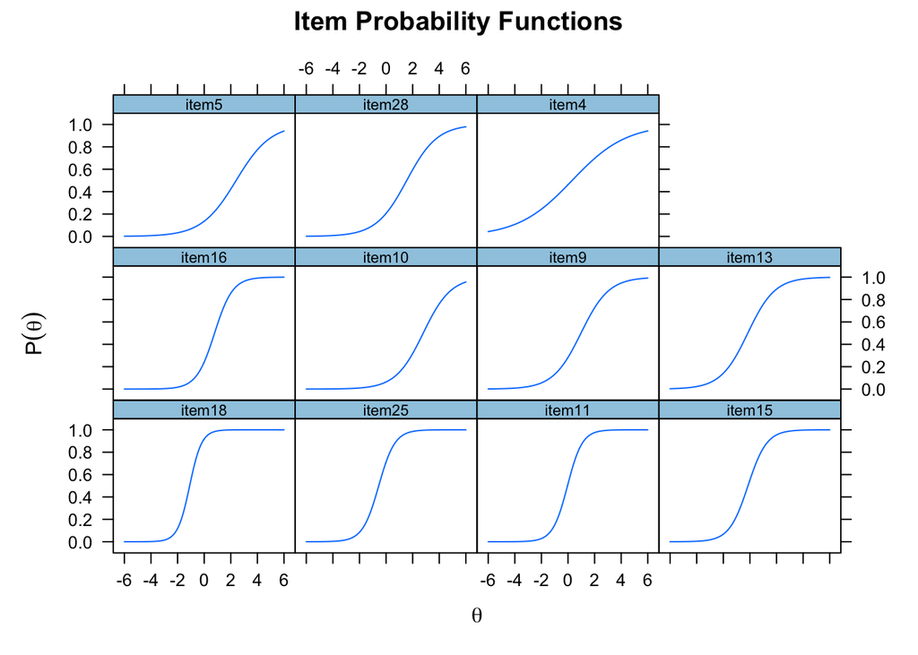

```r
occ_info
```

## 3.13 Bonus: publication quality IRT plots

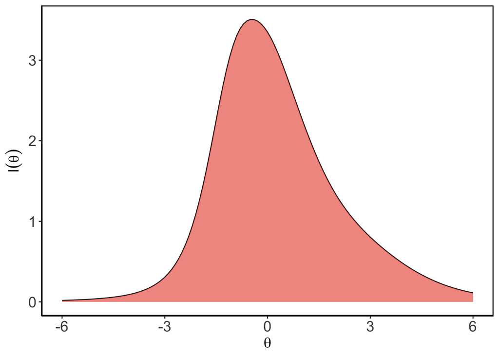

```r
tic <- tabledown::ggtestinfo(Rotter.one.IRT, unidimensional_fit)+
  geom_area()+aes(fill =  "#E64B3599")+theme(legend.position = "none")+
  scale_fill_identity()+xlab(expression(theta))+ylab(expression(I(theta)))+apatheme
tic
```

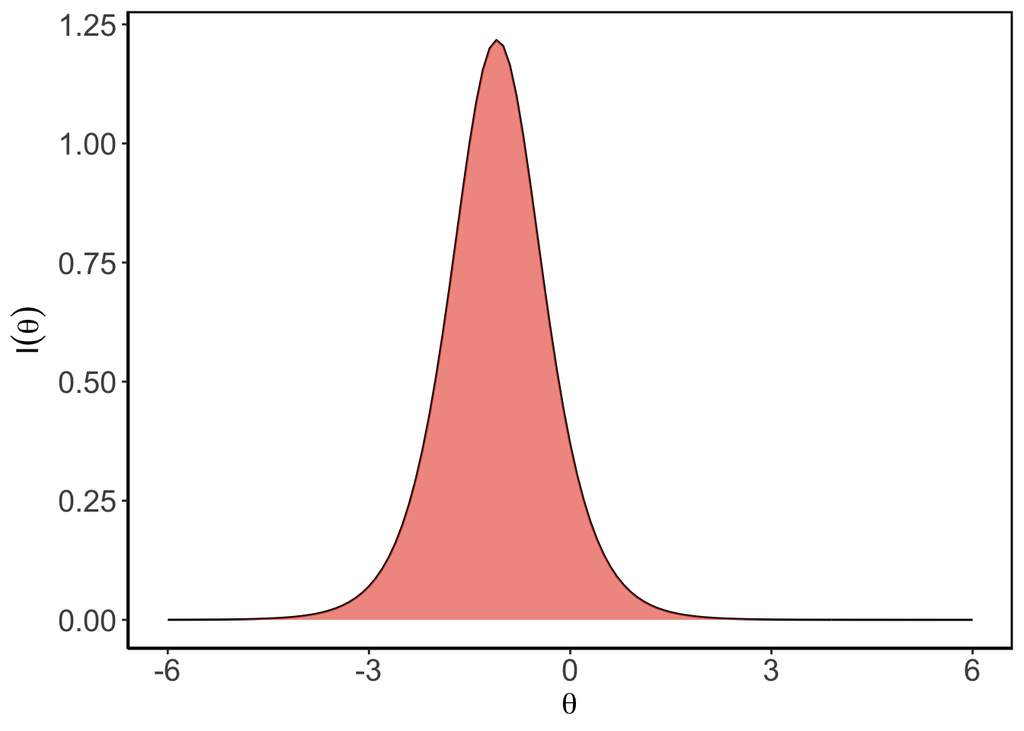

```r
item_info <- tabledown::ggiteminfo(unidimensional_fit, 1,6)+
  geom_area()+aes(fill =  "#E64B3599")+theme(legend.position = "none")+
  scale_fill_identity()+xlab(expression(theta))+ylab(expression(I(theta)))+apatheme

item_info
```

# References

Bentler, P. M., and Chih-Ping Chou. 1987. “Practical Issues in Structural Modeling.” *Sociological Methods & Research* 16 (1): 78–117. https://doi.org/10.1177/0049124187016001004.

Comrey, Andrew Laurence, and Howard Bing Lee. 1992. *A First Course in Factor Analysis, 2nd Ed*. A First Course in Factor Analysis, 2nd Ed. Hillsdale, NJ, US: Lawrence Erlbaum Associates, Inc.

Jackson, Christopher H. 2011. “Multi-State Models for Panel Data: The msm Package for R.” *Journal of Statistical Software* 38 (8): 1–29. http://www.jstatsoft.org/v38/i08/.

Kaiser, Henry F. 1974. “An Index of Factorial Simplicity.” *Psychometrika* 39 (1): 31–36. https://doi.org/10.1007/bf02291575.

Kline, Rex B. 2015. *Principles and Practice of Structural Equation Modeling*. The Guilford Press.

Revelle, William. 2021. *Psych: Procedures for Psychological, Psychometric, and Personality Research*. Evanston, Illinois: Northwestern University. https://CRAN.R-project.org/package=psych.

Schönbrodt, Felix D., and Marco Perugini. 2013. “At What Sample Size Do Correlations Stabilize?” *Journal of Research in Personality* 47 (5): 609–12. https://doi.org/10.1016/j.jrp.2013.05.009.

Sjoberg, Daniel D., Michael Curry, Margie Hannum, Joseph Larmarange, Karissa Whiting, and Emily C. Zabor. 2021. *Gtsummary: Presentation-Ready Data Summary and Analytic Result Tables*. https://CRAN.R-project.org/package=gtsummary.

Worthington, Roger L., and Tiffany A. Whittaker. 2006. “Scale Development Research: A Content Analysis and Recommendations for Best Practices.” *The Counseling Psychologist* 34 (6): 806–38. https://doi.org/10.1177/0011000006288127.